# Assignment 2

Payal Sen

1/29/2020

## GitHub User Description and User Page URL

Set github token

```r
my_token = "154dd284f7b8c8a2f8eb3ca8804c13896fac4af6"
Sys.setenv(GITHUB_TOKEN = my_token)
```

Libraries used

```r
#devtools::install_github("r-lib/gh")
library(httr)
library(devtools)
library(gh)
library(tidyverse)
library(curl)
library (purrr)
library (doParallel)
library(knitr)
library(kableExtra)
library(ggplot2)
library(lubridate)
library(stringr)
library(RColorBrewer)
library(ggthemes)
```

## User’s Basic Information

- In the code below, data for user **mslinn** is read from github api. This list format data is the stored in **user**.
- List data is extracted into a dataframe **user_df**

```r
user <- gh("/users/mslinn", .limit = Inf)

user_df <- data.frame(user_id = user$id,user_name = user$name,
             pub_repos = user$public_repos, followers = user$followers)

kable(user_df,caption = "This table shows the user's id, name, public_repos, followers") %>%
  kable_styling(bootstrap_options = "striped", full_width = F, position = "left",
                fixed_thead = T)
```

This table shows the user’s id, name, public_repos, followers

| user_id | user_name | pub_repos | followers |
| --- | --- | --- | --- |
| 485818 | Mike Slinn | 193 | 69 |

## Followers’ Basic Information

- In the code below, followers data is read from github api. This list format data is stored in **user_followers**.
- Using **map_df**, all follower data was extracted and a dataframe was created with the same name i.e. **user_followers**.
- **Map()** function used to get the user details of each follower.
- Lastly a For loop is run to capture the id, name, public_repos, followers for each follower.
- For some followers name is not blank, they have been replaced by **“NA”**

```r
user_followers <- gh("/users/mslinn/followers", .limit = Inf)

user_followers = map_df(
  user_followers, magrittr::extract, names(user_followers[[1]]))

followers_details =
  map(user_followers$login, ~gh(paste0("/users/", .)))

followers_df = NULL

for (i in seq_along(followers_details)){
  id <- followers_details[[i]]$id
  public_repos <- followers_details[[i]]$public_repos
  followers <- followers_details[[i]]$followers
  if (is.null(followers_details[[i]]$name)){
    name = "NA"
    }
  else{
    name = followers_details[[i]]$name
    }
  followers_df = rbind(followers_df, data.frame(id, name, public_repos, followers))
}


kable(followers_df,
      caption = "This table summarizes followers’ id, name, public_repos and followers.") %>%
  kable_styling(bootstrap_options = "striped", full_width = F, position = "left",
                fixed_thead = T)
```

This table summarizes followers’ id, name, public_repos and followers.

| id | name | public_repos | followers |
| --- | --- | --- | --- |
| 526432 | Greg Wester | 35 | 53 |
| 537224 | Johan Prinsloo | 43 | 35 |
| 1421516 | Takafumi Asano | 18 | 4 |
| 78564 | David Vydra | 23 | 12 |
| 615850 | Yang Jing | 58 | 160 |
| 2371702 | NA | 32 | 16 |
| 4807 | Yousef Ourabi | 59 | 47 |
| 51669 | Yann Simon | 124 | 79 |
| 5723679 | Emily Keyes | 5 | 3 |
| 1429314 | NA | 48 | 15 |
| 2665808 | Alex | 78 | 52 |
| 770124 | Emmanuel Joliet | 16 | 5 |
| 19658 | Kazuhiro Sera | 228 | 413 |
| 4152371 | chengyezhao | 8 | 17 |
| 625947 | Konstantin Läufer | 40 | 110 |
| 1915743 | Marilson Campos | 151 | 3 |
| 3011346 | edwardttril | 4203 | 91 |
| 168835 | NA | 8 | 6 |
| 7440719 | NA | 25 | 4 |
| 59409 | Federico Bucchi | 89 | 93 |
| 25500 | Dennis Lin | 31 | 39 |
| 12591579 | narayanareddy | 273 | 15 |
| 2861171 | NA | 20 | 3 |
| 3659381 | NA | 12 | 2 |
| 4500734 | Felix | 5 | 1 |
| 2639535 | Gregor Wolf | 121 | 170 |
| 1711484 | Nikolaus Rumm | 8 | 0 |
| 9974557 | isdiop | 142 | 6 |
| 17761745 | Arseniy Tashoyan | 42 | 4 |
| 176909 | Roman Kagan | 21 | 7 |
| 2180314 | NA | 174 | 2 |
| 23658754 | NA | 54 | 3 |
| 14280155 | Calvin Lee Fernandes | 91 | 83 |
| 4087541 | Guillermo Guzmán Sánchez | 14 | 1 |
| 148710 | János Setény | 104 | 19 |
| 15696700 | NA | 0 | 0 |
| 303460 | Leonardo Lucena | 89 | 125 |
| 1091037 | Stefan Bacon | 8 | 2 |
| 1733981 | Steve Waldman | 82 | 113 |
| 3446794 | Dennis Ig | 538 | 17 |
| 8035100 | Rahul Muttineni | 85 | 211 |
| 5965567 | Masud Rahman | 29 | 4 |
| 16966437 | Chris | 90 | 35 |
| 7419778 | Linpingchuan | 822 | 19 |
| 8031114 | Fidel Saldivar | 18 | 4 |
| 4625936 | R. Singh | 4 | 1 |
| 27158 | Rudger | 363 | 107 |
| 12975996 | Ejiroghene Oghojafor | 22 | 6 |
| 37007704 | NA | 1 | 184 |
| 8308247 | Cause Chung | 55 | 5 |
| 10077704 | Lisa Zeller | 2 | 1 |
| 21037644 | Dmitry Bugakov | 58 | 17 |
| 782135 | Andrew Martin | 70 | 76 |
| 28345989 | Edmund Cuthbert | 8 | 18 |
| 4757194 | Thierry | 36 | 8 |
| 11889922 | NA | 8 | 10 |
| 23450364 | Uday Kiran Kuchulakanti | 13 | 4 |
| 7200471 | NA | 147 | 177 |
| 5478313 | Sanket Patil | 71 | 20 |
| 1873126 | Venkat Sudheer Reddy Aedama | 28 | 3 |
| 47686772 | NA | 0 | 219 |
| 16507963 | shyan | 76 | 13 |
| 7814757 | NA | 1 | 9 |
| 2291742 | Riccardo Merolla | 55 | 5 |
| 30378238 | Utilisateurs du Québec | 1 | 601 |
| 6598271 | chriniko13 | 112 | 9 |
| 52677285 | NA | 6 | 5 |
| 12669277 | Michael Corrado | 3612 | 33 |
| 1813670 | Moacy Barros | 217 | 3 |

## User’s Repositories Information

- In the code below, repository data is read from github api. This list format data is stored in **user_repos**.
- For loop is run to capture the name, language, size, forks_count, stargazers_count, watchers_count and open_issues_count for each repository.
- For repositories with language as null, it is replaced with **“Unknown”**.

```r
user_repos <- gh("/users/mslinn/repos", .limit = Inf)

repos_df = NULL

for (i in seq_along(user_repos)){
  name <- user_repos[[i]]$name
  size <- user_repos[[i]]$size
  forks_count <- user_repos[[i]]$forks_count
  stargazers_count <- user_repos[[i]]$stargazers_count
  watchers_count <- user_repos[[i]]$watchers_count
  open_issues_count <- user_repos[[i]]$open_issues_count
  if (is.null(user_repos[[i]]$language)){
    language = "Unknown"
  }
  else{
    language = user_repos[[i]]$language
  }
  repos_df = rbind(repos_df, data.frame(name,language,size,forks_count,stargazers_count,
                                  watchers_count,open_issues_count))
}

kable(repos_df,
      caption = "This table summarizes the repositories' name, language, size, forks_count,      stargazers_count, watchers_count, open_issues_count") %>%
  kable_styling(bootstrap_options = "striped", full_width = F, position = "left",
                fixed_thead = T)
```

This table summarizes the repositories’ name, language, size, forks_count, stargazers_count, watchers_count, open_issues_count

| name | language | size | forks_count | stargazers_count | watchers_count | open_issues_count |
| --- | --- | --- | --- | --- | --- | --- |
| activator-akka-stream-scala | HTML | 88 | 0 | 0 | 0 | 0 |
| akka-sample-remote | Scala | 156 | 0 | 1 | 1 | 0 |
| akka-stream-fun | Scala | 14 | 0 | 0 | 0 | 0 |
| akka-streams-alpakka-talk-demos-2016 | Scala | 4493 | 0 | 0 | 0 | 0 |
| akka-websockets-demo | Scala | 53 | 0 | 0 | 0 | 0 |
| AkkaFilter | Scala | 104 | 0 | 0 | 0 | 0 |
| alexa-avs-sample-app | Shell | 14524 | 0 | 0 | 0 | 0 |
| alexa-cookbook | JavaScript | 8019 | 0 | 0 | 0 | 0 |
| audioTest | Java | 25 | 0 | 1 | 1 | 0 |
| aws-ssh-scp-connector | Shell | 44 | 0 | 0 | 0 | 0 |
| awsJavaSamples | Java | 21 | 0 | 0 | 0 | 0 |
| awslib_scala | Scala | 1316 | 3 | 18 | 18 | 6 |
| AwsMirror | Scala | 620 | 0 | 4 | 4 | 7 |
| AwsUpdate | Scala | 399 | 0 | 0 | 0 | 3 |
| barcode | Scala | 218 | 0 | 0 | 0 | 0 |
| beth | Scala | 95 | 0 | 4 | 4 | 5 |
| better-files | Scala | 1582 | 0 | 0 | 0 | 0 |
| bootstrap-input-spinner | Unknown | 182 | 0 | 0 | 0 | 0 |
| bot-builder-fun | Scala | 8 | 0 | 1 | 1 | 0 |
| cake-patter | Scala | 5 | 0 | 0 | 0 | 0 |
| cake-test | Scala | 13 | 0 | 0 | 0 | 0 |
| certbot-route53 | Shell | 11 | 0 | 0 | 0 | 0 |
| chill | Java | 817 | 0 | 0 | 0 | 0 |
| ckeditor-imagebrowser | JavaScript | 130 | 0 | 0 | 0 | 0 |
| cli-loop | Scala | 193 | 0 | 1 | 1 | 4 |
| collection | Unknown | 1409 | 0 | 0 | 0 | 0 |
| commander-scala | Scala | 61 | 0 | 0 | 0 | 0 |
| config | Scala | 206 | 0 | 0 | 0 | 0 |
| configTest | Scala | 120 | 0 | 0 | 0 | 0 |
| ConstructorsPhase | Scala | 108 | 0 | 0 | 0 | 0 |

[output cut: 163 more lines]

## Summary of Issues by Repository

- Issue data is read from user repository and stored in dataframe **mslinn_repos_df**
- For loop is run to capture the total no. of open and closed issues within each repository, and also to calculate the average duration for an issue to close.

```r
mslinn_repos_df <-
  data_frame(
    repo = user_repos %>% map_chr("name"),
    issue = repo %>%
     map(~ gh(repo = .x, endpoint = "/repos/mslinn/:repo/issues?state=all",.limit = #Inf)
                )
                ))

issue_df = NULL


for(i in 1:length(mslinn_repos_df$issue)){
  open = 0
  closed = 0
  duration = 0
  if(length(mslinn_repos_df$issue[[i]])>0){
    for(j in 1:length(mslinn_repos_df[[2]][[i]]))
      if(mslinn_repos_df[[2]][[i]][[j]][["state"]]=='open'){
        open = open+1
      }else{
        closed = closed+1
        duration = duration + ymd_hms(mslinn_repos_df[[2]][[i]][[j]][["closed_at"]]) - ymd_hms(mslinn_repos_df[[2]][[i]][[j]][["created_at"]])
      }
  }
  duration = duration / closed
  duration = as.duration(duration)
  repo = mslinn_repos_df$repo[[i]]
  issue_df = rbind(issue_df, data.frame(repo,open,closed,duration))
}

kable(issue_df,
      caption = "This table summarizes the issues and include columns: repo name, the number of open issues, the number of closed issues, the average duration to close an issue") %>%
  kable_styling(bootstrap_options = "striped", full_width = F, position = "left",
                fixed_thead = T)
```

This table summarizes the issues and include columns: repo name, the number of open issues, the number of closed issues, the average duration to close an issue

| repo | open | closed | duration |
| --- | --- | --- | --- |
| activator-akka-stream-scala | 0 | 0 | NA |
| akka-sample-remote | 0 | 0 | NA |
| akka-stream-fun | 0 | 0 | NA |
| akka-streams-alpakka-talk-demos-2016 | 0 | 0 | NA |
| akka-websockets-demo | 0 | 0 | NA |
| AkkaFilter | 0 | 0 | NA |
| alexa-avs-sample-app | 0 | 0 | NA |
| alexa-cookbook | 0 | 0 | NA |
| audioTest | 0 | 0 | NA |
| aws-ssh-scp-connector | 0 | 0 | NA |
| awsJavaSamples | 0 | 0 | NA |
| awslib_scala | 6 | 24 | 231882.541666667s (~2.68 days) |
| AwsMirror | 7 | 9 | 69454.8888888889s (~19.29 hours) |
| AwsUpdate | 3 | 3 | 391945.666666667s (~4.54 days) |
| barcode | 0 | 0 | NA |
| beth | 5 | 0 | NA |
| better-files | 0 | 0 | NA |
| bootstrap-input-spinner | 0 | 0 | NA |
| bot-builder-fun | 0 | 0 | NA |
| cake-patter | 0 | 0 | NA |
| cake-test | 0 | 0 | NA |
| certbot-route53 | 0 | 0 | NA |
| chill | 0 | 0 | NA |
| ckeditor-imagebrowser | 0 | 0 | NA |
| cli-loop | 4 | 3 | 208241.666666667s (~2.41 days) |
| collection | 0 | 0 | NA |
| commander-scala | 0 | 0 | NA |
| config | 0 | 1 | 200946022s (~6.37 years) |
| configTest | 0 | 0 | NA |
| ConstructorsPhase | 0 | 0 | NA |

[output cut: 163 more lines]

## Plots

### Plot1- shows Mike’s followers with more than 100 public_repos and their followers.

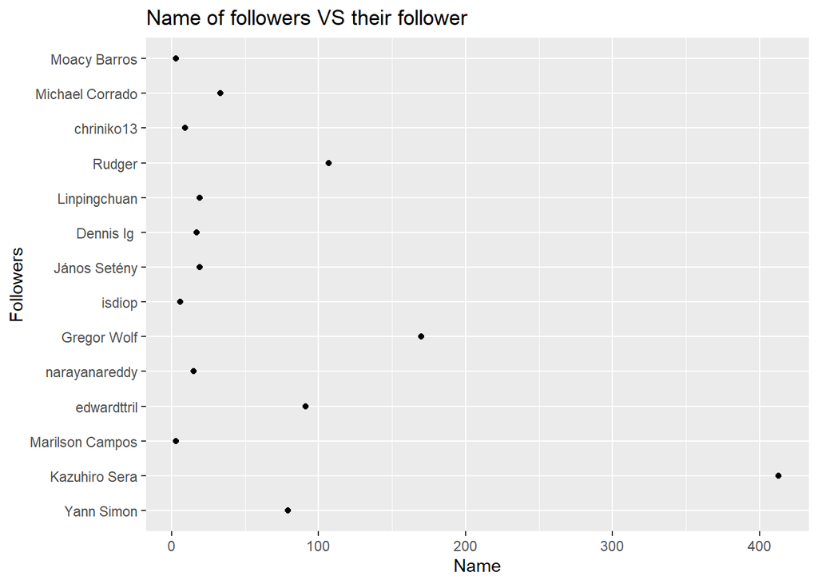

```r
#
plot1 <- ggplot(followers_df%>% filter(public_repos>100) %>% filter(name != 'NA') , aes(x=followers, y=name))+
  geom_point()+
  labs(title="Name of followers VS their follower")+
  xlab("Name")+
  ylab("Followers")

plot1
```

### Plot2- summarizes open issues in each of Mike’s repositories.

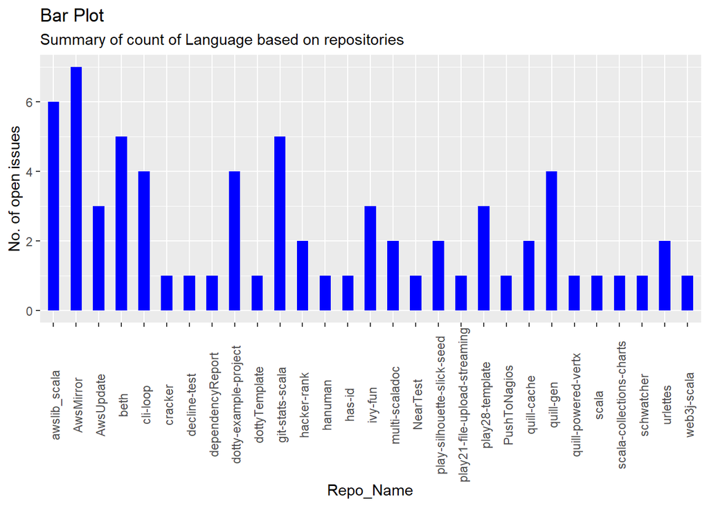

```r
plot2 <- issue_df %>% filter( open > 0 ) %>%
  ggplot(aes(x=repo, y=open)) +
  geom_bar(stat="identity", width=.5, fill="blue") +
  theme(axis.text.x = element_text(angle=90, vjust=0.6))+
  labs(title="Bar Plot",
       subtitle="Summary of count of Language based on repositories")+
       xlab("Repo_Name")+
       ylab("No. of open issues")


plot2
```

### Plot3- Summarizes the count for each language used in Mike’s repositories.

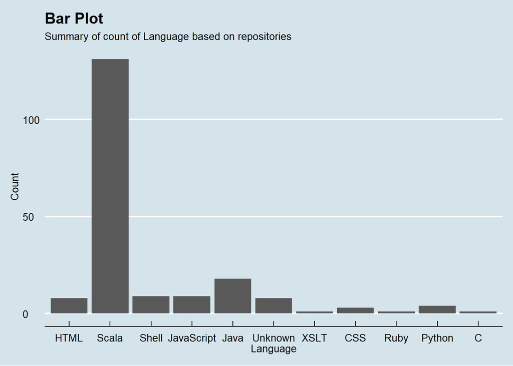

```r
plot3 <- ggplot(repos_df, aes(language)) +
  geom_bar() +
  theme_economist()+
  labs(title="Bar Plot",
       subtitle="Summary of count of Language based on repositories")+
  xlab("Language")+
  ylab("Count")
plot3
```

### Plot4- Summarizes the largest repositories by size and language.

The top 3 repositories are spark, playframework, scala.

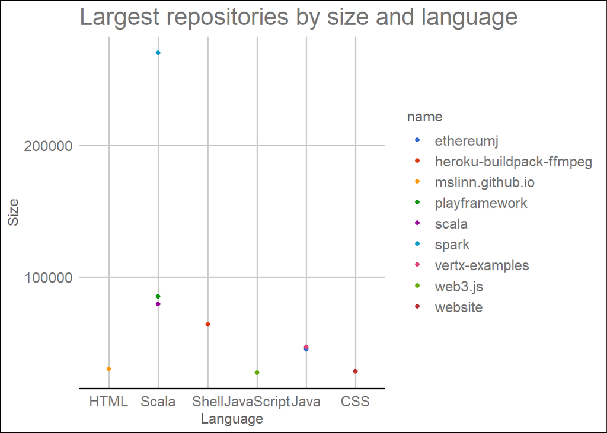

```r
options(scipen = 999)
plot4 <- repos_df %>%
  filter(size > 20000) %>%
  ggplot(aes(language, size, color = name)) + geom_point() +
  labs(title="Largest repositories by size and language") +
  xlab("Language")+
  ylab("Size")+
  theme_gdocs()+
  scale_color_gdocs()
plot4
```